# Similarity Measure

Last Update: 2020-03-22

Consider we have two datasets, Real Dataset and Model Dataset.  
How do we measure the similarities between those two datasets ?

```python
import numpy as np
import pandas as pd
import matplotlib.pyplot as plt
import scipy.spatial
from IPython.display import display, Markdown

import warnings
warnings.filterwarnings('ignore')

%matplotlib inline
```

```python
# --- Load 2 datasets from CSV
ds1 = pd.read_csv( "Similarity-Measure/China-Confirmed.csv")
ds2 = pd.read_csv( "Similarity-Measure/China-Model.csv")

display( Markdown( "## Real Dataset" ))
display( ds1["Confirmed"].values )
display(  Markdown( "## Model Dataset" ))
display( ds2["Confirmed"].values )
```

Real Dataset

```
array([  547.,   639.,   916.,  1399.,  2062.,  2863.,  5494.,  6070.,
        8124.,  9783., 11871., 16607., 19693., 23680., 27409., 30553.,
       34075., 36778., 39790., 42306., 44327., 44699., 59832., 66292.,
       68347., 70446., 72364., 74139., 74546., 74999., 75472., 76922.,
       76938., 77152., 77660., 78065., 78498., 78824., 79251., 79826.,
       80026., 80151., 80271., 80422., 80573., 80652., 80699., 80735.,
       80757., 80921., 80932., 80945., 80977., 81003., 81033., 81058.,
       81102., 81156., 81250., 81305.])
```

Model Dataset

```
array([ 1528.26827475,  1900.35731184,  2360.34007598,  2927.52812283,
        3624.70874313,  4478.36595045,  5518.68249764,  6779.18286917,
        8295.84096884, 10105.45479011, 12243.1057184 , 14738.60193155,
       17611.98338469, 20868.45230385, 24493.45586449, 28448.98591503,
       32672.30727742, 37078.10518808, 41564.37887349, 46021.43485066,
       50342.3961657 , 54433.15046804, 58219.84487636, 61652.80977489,
       64706.80221866, 67378.30010988, 69681.00895965, 71640.75054676,
       73290.631246  , 74667.01941815, 75806.53113532, 76743.99401248,
       77511.23503126, 78136.49560776, 78644.28457121, 79055.51115385,
       79387.77827168, 79655.7518998 , 79871.55129804, 80045.1265022 ,
       80184.60467814, 80296.59698885, 80386.46390517, 80458.54054829,
       80516.3255693 , 80562.63788579, 80599.7457476 , 80629.47238407,
       80653.28207988, 80672.35004896, 80687.61899273, 80699.84477587,
       80709.63324697, 80717.46987812, 80723.74359662, 80728.76592959,
       80732.78637206, 80736.00471629, 80738.58093877, 80740.64312564])
```

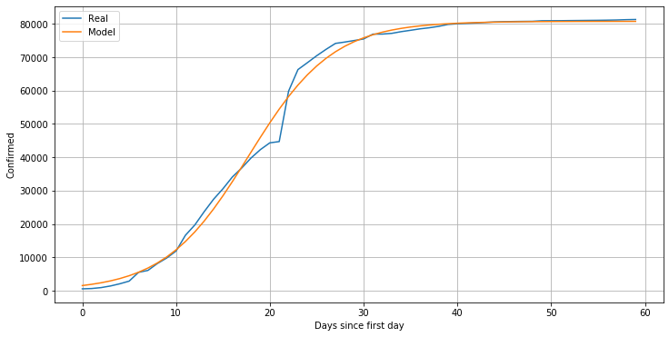

```python
plt.figure(figsize=(12, 6))
plt.plot( ds1["Confirmed"] )
plt.plot( ds2["Confirmed"] )
plt.xlabel('Days since first day')
plt.ylabel('Confirmed')
plt.legend(['Real', "Model"])
plt.grid( True )
```

Some approaches to quantify the similarity:

- Vector Distance
- Correlation

## 1st Approach: Vector Distance

In this approach, the similarity is the inverse of the distance. The range is [0.. $\infty$]. The distance of zero is an extreme similar.  
e.g: **Euclidean Distance**

$\Large d(p,q) = d(q,p) = \sqrt{ (p_1 - q_1)^2 + (p_2 - q_2)^2 + .. + (p_n - q_n)^2 }$

```python
scipy.spatial.distance.euclidean( ds1["Confirmed"], ds2["Confirmed"])
```

```
16129.426212385053
```

This approach is **sensitive** to shifting or scaling.  
e.g. Use sample of COVID-19 outbreak, being shifted by several days, or being scaled due to population difference.

Simply, shifting is addition or substraction, and scaling is multiplication.

## 2nd Approach : Correlation

In this approach, the range is [-1 ... +1]. The correlation of +1 is an extreme similar or to be exact, the two datasets are correlated. The correlation of -1 is an extreme "not similar".

This approach is **insensitive** to shifting and scaling.

$ \Large COV_{ij} = \sigma_i\sigma_j = \frac{1}{N} \sum (x_i - \mu_i) . (x_j - \mu_j) $  
$ \Large CORR_{ij} = \frac{COV_{ij}}{\sqrt{ COV_{ii} . COV_{jj}}} $

```python
corr = np.corrcoef( ds1["Confirmed"], ds2["Confirmed"] )
corr
```

```
array([[1.        , 0.99765864],
       [0.99765864, 1.        ]])
```

```python
corr[0,1]
```

```
0.9976586401698464
```